# Sunk Cost and House Price

DR and VY

March, 2019

# 1 Descriptive Statistics: Complete Sample

```
##
## =====================================================================================================
## Statistic                       Mean        St. Dev.      Pctl(25)      Median      Pctl(75)     N
## -----------------------------------------------------------------------------------------------------
## Purchase_price              499,811.1000  537,238.4000    242,000      380,000      595,000    53,500
## adj_purch_price             658,209.9000  705,617.8000  330,740.3000 497,909.3000 757,297.3000 53,500
## Listing_price               691,406.5000  755,701.8000    350,000      525,000      779,900    53,500
## Listing_premium                1.0693        0.1490        0.9616       1.0434       1.1545    53,500
## Selling_premium                1.0712        4.4263        0.9430       1.0203       1.1216    53,500
## Property_tax_last_year       6,192.9310    6,232.2710    3,155.0230   4,855.0000   7,316.9700  53,500
## Property_tax_rate_last_year    0.0098        0.0028        0.0083       0.0096       0.0110    53,500
## affected_by_prop_8             0.2370        0.4253          0            0            0       52,517
## purchase_hpi                419,342.9000  279,828.1000    238,500      360,600      524,200    53,500
## hpi_inflation                  1.3900        0.4419        1.1292       1.3049       1.5236    53,500
## ownership_years                7.9507        4.6262          4            7            12      53,500
## beds                           3.4256        0.8876          3            3            4       53,493
## baths                          2.4934        0.9805        2.0000       2.0000       3.0000    53,273
## sqft                         2,001.5500    2,048.7730      1,386       1,779.5       2,386     53,458
## LotSizeSquareFeet           20,879.5000  1,013,226.0000    5,590        7,047        9,636     50,717
## house_age                     38.1374       23.9322          17           34           56      53,500
## LTV_prev                       2.6436       55.4270        0.5000       0.7999       0.9397    53,464
## avg_school_rating              6.6611        2.0969        5.0000       6.6667       8.3333    53,456
## avg_school_distance            1.4484        1.2348        0.8000       1.1333       1.7000    53,464
## totalpopulation              5,968.3100    3,053.5150      4,136        5,387        6,884     53,477
## medianage                     39.4914        7.9939       33.7000      38.6000      44.1000    53,475
## medianhouseholdincome       80,012.0700   32,324.6700      56,566       74,688       99,046    53,469
## Renter_fraction                0.3295        0.1720        0.1974       0.3016       0.4387    53,475
## -----------------------------------------------------------------------------------------------------
```

# 2 Descriptive Statistics: Purchases before 2008

```
##
## ===================================================================================================
## Statistic                       Mean       St. Dev.     Pctl(25)      Median      Pctl(75)     N
## ---------------------------------------------------------------------------------------------------
## Purchase_price              510,230.6000 466,700.4000   253,500      403,500      627,000    22,487
## adj_purch_price             675,184.2000 636,420.8000 352,604.0000 528,036.0000 788,393.6000 22,487
## Listing_price               714,460.2000 665,120.6000   379,000      559,000      819,000    22,487
## Listing_premium                1.0735       0.1506       0.9643       1.0497       1.1596    22,487
## Selling_premium                1.0544       1.0508       0.9403       1.0211       1.1227    22,487
## Property_tax_last_year       6,228.2170   5,428.6750   3,236.0000   5,012.0000   7,515.7400  22,487
## Property_tax_rate_last_year    0.0097       0.0029       0.0079       0.0096       0.0112    22,487
## affected_by_prop_8             0.4608       0.4985         0            0            1       22,026
## purchase_hpi                433,884.9000 278,683.8000   242,300      380,200      559,400    22,487
## hpi_inflation                  1.4539       0.6303       0.9907       1.2514       1.7566    22,487
## ownership_years               12.6099       2.8492         11           12           14      22,487
## beds                           3.4247       0.8780         3            3            4       22,484
## baths                          2.5144       1.0439       2.0000       2.0000       3.0000    22,394
## sqft                         2,030.6010    895.3042      1,413        1,829        2,442     22,460
## LotSizeSquareFeet           17,299.9000  135,446.4000    5,600        7,196        10,018    21,291
## house_age                     38.1602      22.9571         18           33           55      22,487
## LTV_prev                       0.6190       0.3554       0.4642       0.7812       0.8000    22,458
## avg_school_rating              6.9516       2.0253       5.3333       7.3333       8.6667    22,463
## avg_school_distance            1.4524       1.2997       0.8000       1.1667       1.7000    22,469
## totalpopulation              5,881.6000   2,976.9320     4,081        5,366        6,801     22,479
## medianage                     40.3807       7.9782      34.7000      39.5000      45.1000    22,477
## medianhouseholdincome       82,688.1500  32,702.6400    58,540.5      77,292      101,590    22,476
## Renter_fraction                0.3200       0.1710       0.1895       0.2912       0.4278    22,477
## ---------------------------------------------------------------------------------------------------
```

# 3 Instrument Validation

## 3.1 California: Within zip code variation of property tax rate

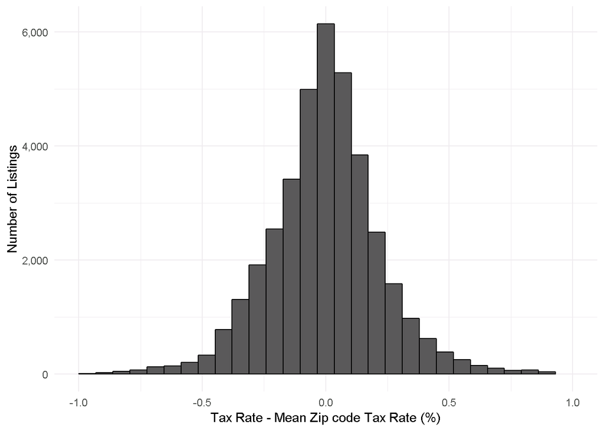

## 3.2 Effect of Years of ownership on Property tax rate (Figure)

Sample: All homes in CA, IL, and NY for which purchase transaction details and property tax amount paid in 2016 (or 2014 for IL) are available. Intra-family transfers and forclosure sales were excluded.

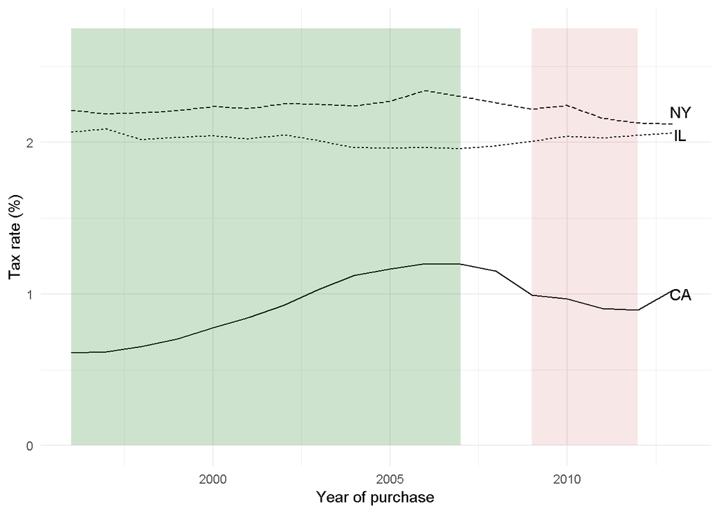

## 3.3 Effect of Years of ownership on Property tax rate (Regression)

Sample: All homes in CA, IL, and NY for which purchase transaction details and property tax amount paid in 2016 (or 2014 for IL) are available **and purchase year is less than 2008**. Intra-family transfers and forclosure sales were excluded.

```
##
## ==================================================
##                           Dependent variable:
##                      -----------------------------
##                         CA        IL        NY
##                         (1)       (2)       (3)
## --------------------------------------------------
## Ownership_years      -0.001***  0.00004  -0.00002
##                      (0.00001) (0.00002) (0.00002)
## log(Adj_purch_price) -0.006*** -0.002*** -0.007***
##                      (0.0002)  (0.0003)   (0.001)
## log(nominal_loss)    -0.00000   0.00001  0.00002**
##                      (0.00001) (0.00001) (0.00001)
## Bedrooms             0.0002***  0.0001
##                      (0.00002) (0.0001)
## Bathrooms            0.001***  0.003***
##                      (0.00003) (0.0001)
## log(House_age)       -0.002*** -0.001*** -0.002***
##                      (0.0001)  (0.0001)  (0.0002)
## --------------------------------------------------
## FE:                     Zip       Zip       Zip
## Cluster:                Zip       Zip       Zip
## Observations         1,722,228  532,796   99,191
## Adjusted R2            0.359     0.444     0.232
## ==================================================
## Note:                  *p<0.1; **p<0.05; ***p<0.01
##
```

## 3.4 First Stage: Effect of Years of Ownership on Tax Rate

Using zillow sample.

```
##
## ===================================================
##                            Dependent variable:
##                        ----------------------------
##                          1996-2007      1996-2007
##                             (1)            (2)
## ---------------------------------------------------
## ownership_years          -0.001***      -0.001***
##                          (0.00001)      (0.00001)
## log(adj_purch_price)     -0.004***      -0.004***
##                           (0.0002)      (0.0002)
## log(nominal_loss)        -0.00002*      -0.00002*
##                          (0.00001)      (0.00001)
## beds                     0.0001***      0.0001***
##                          (0.00005)      (0.00005)
## baths                     0.00000        0.00000
##                          (0.00002)      (0.00002)
## sqft                     0.00000***    0.00000***
##                          (0.00000)      (0.00000)
## avg_school_rating        0.0002***      0.0001***
##                          (0.00004)      (0.00004)
## avg_school_distance        0.0001        0.0001
##                           (0.0001)      (0.0001)
## walk_score               -0.00000**     -0.00000
##                          (0.00000)      (0.00000)
## log(house_age)           -0.001***      -0.001***
##                           (0.0001)      (0.0001)
## log(LotSizeSquareFeet)     0.0001        0.0001
##                           (0.0001)      (0.0001)
## LTV_prev                 0.0003***      0.0003***
##                           (0.0001)      (0.0001)
## medianage                                0.00000
##                                         (0.00001)
## medianhouseholdincome                   0.000***
##                                          (0.000)
## Renter_fraction                          0.0002
##                                         (0.0004)
## ---------------------------------------------------
## FE:                     Zip x Month    Zip x Month
## Cluster:                    Zip            Zip
## Observations               20,367        20,360
## Adjusted R2                0.600          0.603
## ===================================================
## Note:                   *p<0.1; **p<0.05; ***p<0.01
##
```

## 3.5 Direct impact of Z (Years of Ownership) on Y (List Price): Zillow Sample

For the homes purchased between 2009 and 2012, there is no variation in the property tax rate in 2016. Therefore column (2) captures the direct impact of ‘years of ownership’ on listing price.

```
##
## ===================================================
##                            Dependent variable:
##                        ----------------------------
##                          1996-2007      2009-2012
##                             (1)            (2)
## ---------------------------------------------------
## ownership_years          -0.004***        0.003
##                           (0.001)        (0.002)
## log(adj_purch_price)      0.602***      0.625***
##                           (0.019)        (0.026)
## log(nominal_loss)         0.002***        0.013
##                           (0.0004)       (0.014)
## beds                       0.001          0.003
##                           (0.003)        (0.006)
## baths                      0.003        0.022***
##                           (0.003)        (0.007)
## sqft                     0.0001***      0.0001***
##                          (0.00001)      (0.00002)
## avg_school_rating         0.012***       0.006**
##                           (0.003)        (0.003)
## avg_school_distance       -0.0003         0.001
##                           (0.003)        (0.003)
## walk_score               -0.0004***     -0.00001
##                           (0.0001)      (0.0001)
## log(house_age)             0.003        0.025***
##                           (0.005)        (0.006)
## log(LotSizeSquareFeet)    0.030***      0.031***
##                           (0.006)        (0.006)
## LTV_prev                  -0.011**       -0.015*
##                           (0.005)        (0.009)
## ---------------------------------------------------
## FE:                     Zip x Month    Zip x Month
## Cluster:                    Zip            Zip
## Observations               20,367        13,190
## Adjusted R2                0.971          0.977
## ===================================================
## Note:                   *p<0.1; **p<0.05; ***p<0.01
##
```

## 3.6 Direct impact of Z (Years of Ownership) on Y (Quality): ZTRAX Data

This table is based on ZTRAX data. Samples consists of all homes sold in 2015 and 2016 and purchased before 2008. Sample is restricted to the homes for which both the sale details and purchase details are available. Intra-family transfers and foreclosure sales were excluded. If ‘years of ownership’ has a negative direct impact on the quality of the home we should see negative and significant coefficients for IL and NY. FL and TX were exceluded due to property tax system in FL is similar to CA and unavailability of transaction prices respectively.

```
##
## ==========================================================
##                               Dependent variable:
##                      -------------------------------------
##                          CA           IL           NY
##                          (1)          (2)          (3)
## ----------------------------------------------------------
## Ownership_years       -0.004***      0.004       -0.003
##                        (0.001)      (0.004)      (0.008)
## log(Adj_purch_price)  0.871***     0.428***     0.045***
##                        (0.016)      (0.046)      (0.012)
## log(nominal_loss)     0.003***       0.001       0.0004
##                       (0.0005)      (0.003)      (0.008)
## Bedrooms              0.031***       0.002      0.096***
##                        (0.003)      (0.010)      (0.036)
## Bathrooms              -0.001      0.043***     0.167***
##                        (0.003)      (0.016)      (0.045)
## log(House_age)         -0.001       -0.042*     -0.148***
##                        (0.005)      (0.023)      (0.049)
## BuildingAreaSqFt      0.00001**    0.0003***    0.0002***
##                       (0.00001)    (0.00002)    (0.00005)
## ----------------------------------------------------------
## FE:                  Zip x Month Tract x Month Zip x Month
## Cluster:                 Zip          Zip          Zip
## Observations           73,119        8,902       21,907
## Adjusted R2             0.876        0.621        0.299
## ==========================================================
## Note:                          *p<0.1; **p<0.05; ***p<0.01
##
```

# 4 Effect on Listing price (Sample: Homes purchased before 2008)

```
##
## ====================================================================================
##                                                   Dependent variable:
##                                    -------------------------------------------------
##                                        OLS         IV          IV           IV
##                                        (1)         (2)         (3)          (4)
## ------------------------------------------------------------------------------------
## Property_tax_rate_last_year         11.613***
##                                      (0.823)
## log(adj_purch_price)                0.647***    0.632***    0.624***     0.585***
##                                      (0.019)     (0.020)     (0.020)      (0.045)
## log(nominal_loss)                   0.001***    0.002***    0.002***       0.001
##                                     (0.0004)    (0.0004)    (0.0004)      (0.001)
## beds                                 -0.001      -0.0002      0.001        0.004
##                                      (0.003)     (0.003)     (0.003)      (0.008)
## baths                                 0.003       0.003       0.003        0.002
##                                      (0.003)     (0.003)     (0.003)      (0.008)
## sqft                                0.0001***   0.0001***   0.0001***    0.0001***
##                                     (0.00001)   (0.00001)   (0.00001)    (0.00002)
## avg_school_rating                   0.011***    0.011***    0.009***       0.009
##                                      (0.003)     (0.003)     (0.003)      (0.010)
## avg_school_distance                  -0.001      -0.001      -0.002        0.006
##                                      (0.003)     (0.003)     (0.003)      (0.011)
## walk_score                         -0.0004***  -0.0004***   -0.0002**     -0.001*
##                                     (0.0001)    (0.0001)    (0.0001)     (0.0004)
## log(house_age)                      0.014***     0.010*       0.009       -0.002
##                                      (0.005)     (0.005)     (0.005)      (0.014)
## log(LotSizeSquareFeet)              0.028***    0.029***    0.029***      0.033**
##                                      (0.005)     (0.005)     (0.006)      (0.013)
## LTV_prev                            -0.014***   -0.014***   -0.012**      -0.012
##                                      (0.005)     (0.005)     (0.005)      (0.012)
## medianage                                                   0.001***
##                                                             (0.0005)
## medianhouseholdincome                                        0.00000
##                                                             (0.00000)
## Renter_fraction                                              -0.003
##                                                              (0.019)
## `Property_tax_rate_last_year(fit)`              8.087***    8.055***     10.132***
##                                                  (1.214)     (1.211)      (3.432)
## ------------------------------------------------------------------------------------
## Cond. F. Stat                                    160.01      126.11        23.16
## Fixed Effects                      Zip X Month Zip x Month Zip X Month Tract X Month
## Cluster                                Zip         Zip         zip         Tract
## Observations                         20,367      20,367      20,360       20,363
## Adjusted R2                           0.972       0.972       0.972        0.975
## ====================================================================================
## Note:                                                    *p<0.1; **p<0.05; ***p<0.01
##
```

# 5 Effect on Listing price: Variation by Expected Loss

```
##
## ====================================================================================================================
##                                                                   Dependent variable:
##                                    ---------------------------------------------------------------------------------
##                                    OLS-HPIp>HPIl OLS-HPIp<HPIl IV-HPIp>HPIl IV-HPIp<HPIl IV-Prop 8 = 1 IV-Prop 8 = 0
##                                         (1)           (2)          (3)          (4)           (5)           (6)
## --------------------------------------------------------------------------------------------------------------------
## Property_tax_rate_last_year          14.623***     11.131***
##                                       (2.329)       (1.041)
## log(adj_purch_price)                 0.764***      0.613***      1.239***     0.598***     0.805***      0.587***
##                                       (0.044)       (0.023)      (0.337)      (0.023)       (0.034)       (0.029)
## log(nominal_loss)                     0.014**                     0.006                    0.004***       0.005**
##                                       (0.006)       (0.000)      (0.012)      (0.000)       (0.001)       (0.002)
## beds                                  -0.013         0.002        -0.014       0.002        -0.007         0.003
##                                       (0.008)       (0.004)      (0.019)      (0.004)       (0.006)       (0.005)
## baths                                 0.00001        0.007        0.001        0.007         0.001         0.008
##                                       (0.001)       (0.005)      (0.002)      (0.005)       (0.002)       (0.006)
## sqft                                 0.0001***     0.0001***     -0.0001     0.0001***     0.0001***     0.0001***
##                                      (0.00001)     (0.00001)     (0.0001)    (0.00001)     (0.00001)     (0.00001)
## avg_school_rating                     0.011*       0.010***       -0.010      0.011***       0.006        0.008**
##                                       (0.006)       (0.003)      (0.020)      (0.003)       (0.005)       (0.004)
## avg_school_distance                   0.0002        -0.002        -0.009       -0.002       -0.0003       -0.004
##                                       (0.007)       (0.003)      (0.019)      (0.003)       (0.005)       (0.005)
## walk_score                            -0.0004      -0.0003**      0.0002     -0.0003**     -0.0003*     -0.0005***
##                                      (0.0003)      (0.0002)      (0.001)      (0.0002)     (0.0002)      (0.0002)
## log(house_age)                         0.017        0.014*        0.108        0.009        0.023**        0.009
##                                       (0.012)       (0.007)      (0.066)      (0.007)       (0.010)       (0.009)
## log(LotSizeSquareFeet)               0.033***      0.028***       0.021       0.028***     0.025***      0.037***
##                                       (0.011)       (0.007)      (0.025)      (0.008)       (0.007)       (0.009)
## LTV_prev                              -0.0002      -0.018***      -0.043     -0.017***      -0.020*      -0.015**
##                                       (0.015)       (0.006)      (0.044)      (0.006)       (0.011)       (0.008)
## `Property_tax_rate_last_year(fit)`                               94.781*      7.024***     20.369***     11.438***
##                                                                  (56.647)     (1.327)       (5.224)       (1.702)
## --------------------------------------------------------------------------------------------------------------------
## Cond. F. Stat                                                      0.21        147.96        6.21         131.68
## Observations                           5,178        15,189        5,178        15,189        9,171        10,871
## Adjusted R2                            0.969         0.972        0.867        0.972         0.973         0.972
## ====================================================================================================================
## Note:                                                                                    *p<0.1; **p<0.05; ***p<0.01
##                                                                      Fixed Effects: Zip X Month, SE Clustered by Zip
```

# 6 Effect on Listing price: Variation by Property Price Category

```
##
## ==================================================================================================
##                                                          Dependent variable:
##                                    ---------------------------------------------------------------
##                                    Low Value (OLS) Low Value (IV) High Value (OLS) High Value (IV)
##                                          (1)            (2)             (3)              (4)
## --------------------------------------------------------------------------------------------------
## Property_tax_rate_last_year           8.257***                       12.459***
##                                        (1.206)                        (1.639)
## log(adj_purch_price)                  0.499***        0.479***        0.561***        0.570***
##                                        (0.026)        (0.026)         (0.039)          (0.039)
## log(nominal_loss)                      -0.0003         0.0005          0.001            0.001
##                                        (0.001)        (0.001)         (0.001)          (0.001)
## beds                                   0.012**        0.013**         -0.011**        -0.011**
##                                        (0.005)        (0.005)         (0.005)          (0.005)
## baths                                   0.002          0.002           0.0004          0.0004
##                                        (0.007)        (0.007)         (0.003)          (0.003)
## sqft                                  0.0001***      0.0001***       0.0001***        0.0001***
##                                       (0.00001)      (0.00001)       (0.00001)        (0.00001)
## avg_school_rating                      0.010**        0.011***         0.007            0.007
##                                        (0.004)        (0.004)         (0.005)          (0.005)
## avg_school_distance                    -0.004          -0.004         -0.0002          -0.001
##                                        (0.005)        (0.005)         (0.005)          (0.005)
## walk_score                             -0.0002        -0.0002         -0.0004*        -0.0004*
##                                       (0.0002)        (0.0002)        (0.0002)        (0.0002)
## log(house_age)                          0.008          0.002          0.023**         0.025***
##                                        (0.009)        (0.009)         (0.009)          (0.009)
## log(LotSizeSquareFeet)                 0.015*          0.016*         0.048***        0.047***
##                                        (0.009)        (0.009)         (0.008)          (0.008)
## LTV_prev                               -0.001          0.0002         -0.020**        -0.020**
##                                        (0.007)        (0.007)         (0.010)          (0.010)
## `Property_tax_rate_last_year(fit)`                     3.597*                         14.066***
##                                                       (1.871)                          (2.332)
## --------------------------------------------------------------------------------------------------
## Cond. F. Stat                                           54.9                            40.44
## Observations                           10,002          10,002          10,117          10,117
## Adjusted R2                             0.975          0.975           0.975            0.975
## ==================================================================================================
## Note:                                                                  *p<0.1; **p<0.05; ***p<0.01
##                                                    Fixed Effects: Zip X Month, SE Clustered by Zip
```

# 7 Effect on Listing price: Variation by Cold and Hot Markets

Cold: Last 3 year house price growth less than median  
Hot: Last 3 year house price growth greater than median

```
##
## =====================================================================================
##                                                   Dependent variable:
##                                    --------------------------------------------------
##                                     Cold (OLS)    Cold (IV)    Hot (OLS)   Hot (IV)
##                                         (1)          (2)          (3)         (4)
## -------------------------------------------------------------------------------------
## Property_tax_rate_last_year          12.354***                 10.460***
##                                       (1.073)                   (1.249)
## log(adj_purch_price)                 0.669***      0.653***    0.603***    0.589***
##                                       (0.023)      (0.024)      (0.034)     (0.034)
## log(nominal_loss)                     0.001**      0.002***     0.001*      0.002**
##                                      (0.0005)      (0.0005)     (0.001)     (0.001)
## beds                                  0.0004        0.001       -0.003      -0.002
##                                       (0.004)      (0.004)      (0.005)     (0.005)
## baths                                  0.002        0.002        0.008       0.007
##                                       (0.002)      (0.003)      (0.007)     (0.007)
## sqft                                 0.0001***    0.0001***    0.0001***   0.0001***
##                                      (0.00001)    (0.00001)    (0.00001)   (0.00001)
## avg_school_rating                     0.008**      0.008**     0.016***    0.016***
##                                       (0.003)      (0.003)      (0.004)     (0.004)
## avg_school_distance                   -0.002        -0.002       0.001       0.001
##                                       (0.003)      (0.003)      (0.006)     (0.006)
## walk_score                          -0.0004***    -0.0004***   -0.0004*    -0.0004**
##                                      (0.0001)      (0.0001)    (0.0002)    (0.0002)
## log(house_age)                        0.010*        0.006       0.021**     0.018*
##                                       (0.006)      (0.006)      (0.010)     (0.010)
## log(LotSizeSquareFeet)               0.027***      0.028***     0.029**     0.029**
##                                       (0.006)      (0.006)      (0.013)     (0.013)
## LTV_prev                             -0.018***    -0.018***     -0.007      -0.006
##                                       (0.006)      (0.006)      (0.008)     (0.008)
## `Property_tax_rate_last_year(fit)`                 8.564***                7.370***
##                                                    (1.445)                  (2.239)
## -------------------------------------------------------------------------------------
## Cond. F. Stat                                       117.15                   45.94
## Observations                          13,055        13,055       7,312       7,312
## Adjusted R2                            0.967        0.967        0.977       0.977
## =====================================================================================
## Note:                                                     *p<0.1; **p<0.05; ***p<0.01
##                                       Fixed Effects: Zip X Month, SE Clustered by Zip
```

# 8 Effect on Listing price: Variation by Market Activity

```
##
## ==============================================================================================================
##                                                                Dependent variable:
##                                    ---------------------------------------------------------------------------
##                                    Low Activity (OLS) Low Activity (IV) High Activity (OLS) High Activity (IV)
##                                           (1)                (2)                (3)                (4)
## --------------------------------------------------------------------------------------------------------------
## Property_tax_rate_last_year            13.009***                             10.876***
##                                         (1.377)                               (1.034)
## log(adj_purch_price)                    0.696***          0.681***           0.613***            0.597***
##                                         (0.028)            (0.028)            (0.028)            (0.028)
## log(nominal_loss)                        0.001             0.002**            0.001**            0.002***
##                                         (0.001)            (0.001)           (0.0004)            (0.0005)
## beds                                     -0.001            -0.001             -0.001             -0.0003
##                                         (0.006)            (0.006)            (0.004)            (0.004)
## baths                                    0.009              0.009             0.009**             0.009*
##                                         (0.006)            (0.006)            (0.004)            (0.005)
## sqft                                   0.0001***          0.0001***          0.0001***          0.0001***
##                                        (0.00001)          (0.00001)          (0.00001)          (0.00001)
## avg_school_rating                       0.014***          0.014***           0.010***            0.010***
##                                         (0.005)            (0.005)            (0.003)            (0.003)
## avg_school_distance                      -0.003            -0.003             -0.0004            -0.00001
##                                         (0.005)            (0.005)            (0.004)            (0.004)
## walk_score                              -0.0002            -0.0002           -0.001***          -0.001***
##                                         (0.0002)          (0.0002)           (0.0001)            (0.0001)
## log(house_age)                           0.013              0.010            0.019***             0.014*
##                                         (0.009)            (0.009)            (0.007)            (0.007)
## log(LotSizeSquareFeet)                  0.024***          0.025***           0.031***            0.032***
##                                         (0.009)            (0.009)            (0.008)            (0.008)
## LTV_prev                                 -0.015            -0.014            -0.015**            -0.014**
##                                         (0.009)            (0.009)            (0.006)            (0.006)
## `Property_tax_rate_last_year(fit)`                        8.764***                               7.421***
##                                                            (2.122)                               (1.454)
## --------------------------------------------------------------------------------------------------------------
## Cond. F. Stat                                               64.71                                 98.36
## Observations                             8,963              8,963             10,328              10,328
## Adjusted R2                              0.969              0.968              0.969              0.969
## ==============================================================================================================
## Note:                                                                              *p<0.1; **p<0.05; ***p<0.01
##                                                                Fixed Effects: Zip X Month, SE Clustered by Zip
```

# 9 Effect on Listing price: Variation by Loan-to-Value Ratio

```
##
## =====================================================================================
##                                                   Dependent variable:
##                                    --------------------------------------------------
##                                    LTV<.7 (OLS)  LTV<.7 (IV) LTV>.7 (OLS) LTV>.7 (IV)
##                                         (1)          (2)         (3)          (4)
## -------------------------------------------------------------------------------------
## Property_tax_rate_last_year          14.679***                10.004***
##                                       (1.965)                  (1.216)
## log(adj_purch_price)                 0.703***     0.698***     0.620***    0.604***
##                                       (0.043)      (0.044)     (0.027)      (0.027)
## log(nominal_loss)                      0.001        0.001      0.002***    0.002***
##                                       (0.001)      (0.001)     (0.001)      (0.001)
## beds                                   0.001        0.001       0.001        0.001
##                                       (0.007)      (0.007)     (0.005)      (0.005)
## baths                                  0.005        0.005       0.002        0.002
##                                       (0.008)      (0.008)     (0.003)      (0.003)
## sqft                                 0.0001***    0.0001***   0.0001***    0.0001***
##                                      (0.00002)    (0.00002)   (0.00001)    (0.00001)
## avg_school_rating                      0.008        0.008      0.012***    0.013***
##                                       (0.006)      (0.006)     (0.003)      (0.003)
## avg_school_distance                   -0.001       -0.001       -0.001      -0.0005
##                                       (0.006)      (0.006)     (0.004)      (0.004)
## walk_score                            -0.0004      -0.0004    -0.0004***  -0.0004***
##                                      (0.0003)     (0.0003)     (0.0001)    (0.0001)
## log(house_age)                         0.010        0.009       0.010        0.006
##                                       (0.013)      (0.013)     (0.007)      (0.007)
## log(LotSizeSquareFeet)               0.028***     0.028***     0.030***    0.030***
##                                       (0.010)      (0.010)     (0.007)      (0.007)
## LTV_prev                             -0.053***    -0.052***     0.103        0.097
##                                       (0.016)      (0.016)     (0.067)      (0.064)
## `Property_tax_rate_last_year(fit)`                13.739***                6.403***
##                                                    (3.345)                  (1.690)
## -------------------------------------------------------------------------------------
## Cond. F. Stat                                       25.12                    92.4
## Observations                           7,936        7,936       12,431      12,431
## Adjusted R2                            0.975        0.975       0.970        0.970
## =====================================================================================
## Note:                                                     *p<0.1; **p<0.05; ***p<0.01
##                                       Fixed Effects: Zip X Month, SE Clustered by Zip
```

# 10 Effect on Listing price: Variation by Census tract median age

```
##
## ==========================================================================================
##                                                      Dependent variable:
##                                    -------------------------------------------------------
##                                    Low Age (OLS) Low Age (IV) High Age (OLS) High Age (IV)
##                                         (1)          (2)           (3)            (4)
## ------------------------------------------------------------------------------------------
## Property_tax_rate_last_year          7.545***                   14.316***
##                                       (1.443)                    (1.197)
## log(adj_purch_price)                 0.517***      0.508***      0.686***      0.670***
##                                       (0.032)      (0.033)       (0.024)        (0.025)
## log(nominal_loss)                     0.0003        0.001        0.002***      0.002***
##                                       (0.001)      (0.001)       (0.001)        (0.001)
## beds                                  -0.0002      -0.0002        -0.001        -0.0002
##                                       (0.006)      (0.006)       (0.004)        (0.004)
## baths                                  0.001        0.001        0.011**        0.011**
##                                       (0.001)      (0.001)       (0.005)        (0.005)
## sqft                                 0.0001***    0.0001***     0.0001***      0.0001***
##                                      (0.00001)    (0.00001)     (0.00001)      (0.00001)
## avg_school_rating                     0.011**      0.012***      0.010**        0.011**
##                                       (0.004)      (0.004)       (0.004)        (0.004)
## avg_school_distance                   -0.004        -0.003        -0.001        -0.001
##                                       (0.005)      (0.005)       (0.004)        (0.004)
## walk_score                           -0.0005**    -0.0005**     -0.0004**      -0.0003**
##                                      (0.0002)      (0.0002)      (0.0002)      (0.0002)
## log(house_age)                        -0.010        -0.013       0.019**        0.015*
##                                       (0.010)      (0.010)       (0.008)        (0.008)
## log(LotSizeSquareFeet)               0.040***      0.041***      0.028***      0.028***
##                                       (0.013)      (0.013)       (0.007)        (0.007)
## LTV_prev                              -0.008        -0.008       -0.020**      -0.019**
##                                       (0.008)      (0.008)       (0.008)        (0.008)
## `Property_tax_rate_last_year(fit)`                 5.721**                     10.349***
##                                                    (2.327)                      (1.801)
## ------------------------------------------------------------------------------------------
## Cond. F. Stat                                       32.42                        103.1
## Observations                           7,811        7,811         12,425        12,425
## Adjusted R2                            0.966        0.966         0.971          0.970
## ==========================================================================================
## Note:                                                          *p<0.1; **p<0.05; ***p<0.01
##                                            Fixed Effects: Zip X Month, SE Clustered by Zip
```

# 11 Effect on Listing price: Variation by Census tract median household income

```
##
## ======================================================================================================
##                                                            Dependent variable:
##                                    -------------------------------------------------------------------
##                                    Low Income (OLS) Low Income (IV) High Income (OLS) High Income (IV)
##                                          (1)              (2)              (3)              (4)
## ------------------------------------------------------------------------------------------------------
## Property_tax_rate_last_year           10.363***                         11.841***
##                                        (1.740)                           (1.143)
## log(adj_purch_price)                   0.625***        0.620***         0.631***          0.614***
##                                        (0.035)          (0.037)          (0.026)          (0.027)
## log(nominal_loss)                      0.002**          0.002**          0.0004           0.001**
##                                        (0.001)          (0.001)         (0.0005)          (0.001)
## beds                                    -0.002          -0.003          -0.00002           0.001
##                                        (0.008)          (0.008)          (0.004)          (0.004)
## baths                                   0.001            0.001            0.007            0.007
##                                        (0.003)          (0.003)          (0.004)          (0.004)
## sqft                                  0.0001***        0.0001***        0.0001***        0.0001***
##                                       (0.00002)        (0.00002)        (0.00001)        (0.00001)
## avg_school_rating                       0.008            0.008          0.010***          0.010***
##                                        (0.006)          (0.006)          (0.004)          (0.004)
## avg_school_distance                     0.004            0.004           -0.003            -0.003
##                                        (0.007)          (0.007)          (0.004)          (0.004)
## walk_score                             -0.0004*        -0.0004*        -0.0004***        -0.0004***
##                                        (0.0002)        (0.0003)         (0.0001)          (0.0001)
## log(house_age)                          -0.002          -0.003          0.021***          0.016**
##                                        (0.011)          (0.011)          (0.007)          (0.007)
## log(LotSizeSquareFeet)                 0.042***        0.042***         0.026***          0.027***
##                                        (0.010)          (0.010)          (0.007)          (0.007)
## LTV_prev                                0.002            0.002          -0.024***        -0.023***
##                                        (0.010)          (0.010)          (0.007)          (0.007)
## `Property_tax_rate_last_year(fit)`                      8.983**                           8.136***
##                                                         (3.567)                           (1.514)
## ------------------------------------------------------------------------------------------------------
## Cond. F. Stat                                            18.18                             122.09
## Observations                            7,098            7,098           13,239            13,239
## Adjusted R2                             0.956            0.956            0.967            0.967
## ======================================================================================================
## Note:                                                                      *p<0.1; **p<0.05; ***p<0.01
##                                                        Fixed Effects: Zip X Month, SE Clustered by Zip
```

# 12 Transaction Outcome

## 12.1 Effect of property tax rate on Transaction outcome (Zillow Sample)

```
##
## ========================================================================================
##                                                     Dependent variable:
##                                    -----------------------------------------------------
##                                    OLS (Sale Price) IV (Sale Price) OLS (Time) IV (Time)
##                                          (1)              (2)          (3)        (4)
## ----------------------------------------------------------------------------------------
## Property_tax_rate_last_year           13.603***                       -3.271
##                                        (1.665)                       (3.069)
## log(adj_purch_price)                   0.660***        0.634***       -0.004     0.015
##                                        (0.033)          (0.034)      (0.040)    (0.046)
## log(nominal_loss)                       0.0001           0.001       0.004**     0.003
##                                        (0.001)          (0.001)      (0.002)    (0.002)
## beds                                    0.0001           0.001        -0.003    -0.003
##                                        (0.008)          (0.008)      (0.011)    (0.012)
## baths                                   0.0004          0.0004        0.015*    0.015*
##                                        (0.003)          (0.003)      (0.009)    (0.009)
## sqft                                  0.0001***        0.0001***    0.0001***  0.0001***
##                                       (0.00001)        (0.00001)    (0.00002)  (0.00002)
## avg_school_rating                      0.014***        0.015***      -0.018**  -0.019**
##                                        (0.005)          (0.005)      (0.008)    (0.008)
## avg_school_distance                     -0.010          -0.009        0.004      0.004
##                                        (0.008)          (0.008)      (0.009)    (0.009)
## walk_score                             -0.0004*        -0.0004*      -0.00001   0.00000
##                                        (0.0002)        (0.0002)      (0.0004)  (0.0004)
## log(house_age)                          0.019            0.012        0.008      0.013
##                                        (0.012)          (0.012)      (0.017)    (0.018)
## log(LotSizeSquareFeet)                 0.025**          0.025**      0.025**    0.025**
##                                        (0.011)          (0.011)      (0.012)    (0.012)
## LTV_prev                                -0.006          -0.005        0.009      0.008
##                                        (0.011)          (0.012)      (0.021)    (0.021)
## `Property_tax_rate_last_year(fit)`                      7.587**                  1.082
##                                                         (2.975)                 (5.704)
## ----------------------------------------------------------------------------------------
## Cond. F. Stat                                           160.01                  160.01
## Observations                            20,367          20,367        20,367    20,367
## Adjusted R2                             0.800            0.800        0.341      0.341
## ========================================================================================
## Note:                                                        *p<0.1; **p<0.05; ***p<0.01
##                                          Fixed Effects: Zip X Month, SE Clustered by Zip
```

## 12.2 Effect of property tax rate on Log(Sale Price) (ZTRAX Data)

Sample: Homes purchased before 2008 and at least two years of ownership. Both sales transactions details and purchase transaction details should be available to be included in the sample. Intra-family transfers and foreclosure sales were excluded.

```
##
## =====================================================================
##                                    Dependent variable:
##                      ------------------------------------------------
##                          OLS (Sale Price)         IV (Sale Price)
##                                (1)                      (2)
## ---------------------------------------------------------------------
## Tax_rate                    12.569***
##                              (0.729)
## log(Adj_purch_price)         0.836***                0.819***
##                              (0.010)                  (0.011)
## log(nominal_loss)            0.001***                0.003***
##                              (0.0003)                (0.0004)
## Bedrooms                     0.016***                0.017***
##                              (0.002)                  (0.002)
## Bathrooms                     -0.002                  -0.002
##                              (0.002)                  (0.002)
## BuildingAreaSqFt            0.00005***               0.0001***
##                             (0.00000)                (0.00000)
## log(House_age)               0.016***                0.010***
##                              (0.003)                  (0.003)
## `Tax_rate(fit)`                                      5.364***
##                                                       (1.054)
## ---------------------------------------------------------------------
## Cond. F. Stat                                         123.71
## Observations                  88,961                  88,961
## Adjusted R2                   0.962                    0.962
## =====================================================================
## Note:                                     *p<0.1; **p<0.05; ***p<0.01
##                       Fixed Effects: Zip X Month, SE Clustered by Zip
```

# 13 Using June Cutoff for assessment of new purchases

## 13.1 2016 assesssment of homes purchased in 2015

Assessment value of properties purchased after June 1st in a given year is reset to the purchase price in the subsequent year. Depending on whether the buyer purchased the home just before the June 1st or just after, there is a small difference in the property tax paid in subsequent years, all else equal.

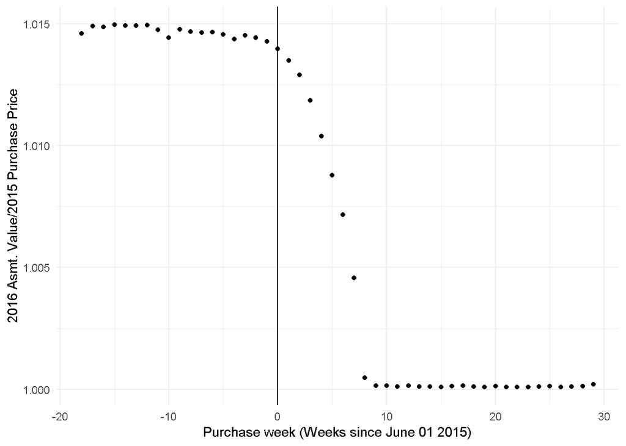

## 13.2 Discoutinuity around June 01 (RD Plots)

Sample is restricted to properties purchased in 2009 to 2012. During this period house prices were stable and there was no upward or downward trend around the cutoff. Therefore if identical properties were purchased just before and just after June 01, buyer would have paid the same price.

Bottom 3 panels show that, if the buyer puchased the home after June 01 in a given year  
* Property taxes paid just before listing is lower * List the home at a slightly lower price * Eventually sells at a slightly lower price

**All plots absorb $zipcode \times purchaseyear \times listyear$ fixed effects. When indicated by a *, $log(Adj purch price)$ was also used as an additional control.**

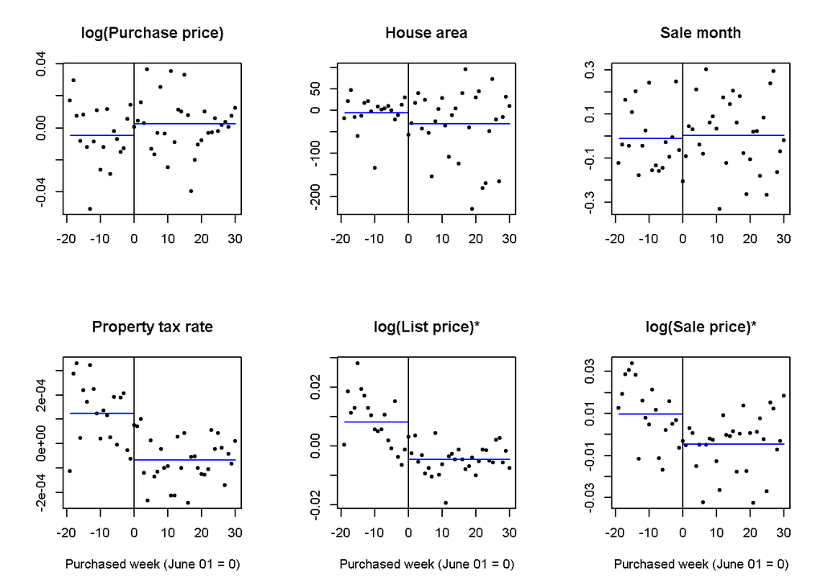

## 13.3 Discoutinuity around June 01 (RD Regression)

```
##
## =========================================================================================================
##                                                       Dependent variable:
##                        ----------------------------------------------------------------------------------
##                         Tax Rate  log(Listing price) log(Selling price) log(Purchase price) Sale Month No
##                           (1)            (2)                (3)                 (4)              (5)
## ---------------------------------------------------------------------------------------------------------
## purchase_after_june01  -0.0002***     -0.012***           -0.009*            0.020***           0.017
##                        (0.00005)       (0.003)            (0.006)             (0.005)          (0.082)
## log(adj_purch_price)   -0.002***       0.618***           0.611***
##                         (0.0002)       (0.017)            (0.022)
## log(HPI_purchase)                                                            0.631***
##                                                                               (0.081)
## beds                    0.0001**        0.001              -0.017             0.015*           -0.026
##                        (0.00005)       (0.003)            (0.015)             (0.009)          (0.067)
## baths                   -0.0001        0.016***           0.014**            0.029***           0.004
##                         (0.0001)       (0.004)            (0.007)             (0.011)          (0.085)
## sqft                   0.00000***     0.0001***          0.0001***           0.0002***         0.0001
##                        (0.00000)      (0.00001)          (0.00001)           (0.00002)        (0.0001)
## avg_school_rating       0.00005        0.006***            0.005             0.040***           0.058
##                        (0.00004)       (0.002)            (0.004)             (0.006)          (0.050)
## avg_school_distance      0.0001         0.002              0.002              -0.0002           0.004
##                         (0.0001)       (0.002)            (0.005)             (0.005)          (0.048)
## walk_score             -0.00000**      -0.0001            -0.0004            -0.001***         0.0001
##                        (0.00000)       (0.0001)           (0.0003)           (0.0002)          (0.002)
## log(house_age)         -0.001***       0.022***           0.017**            -0.080***          0.115
##                         (0.0001)       (0.004)            (0.008)             (0.009)          (0.082)
## log(LotSizeSquareFeet)  -0.0001        0.030***           0.028***           0.073***          -0.124*
##                         (0.0001)       (0.004)            (0.006)             (0.010)          (0.070)
## LTV_prev                0.00001       -0.017***            -0.004              0.012            0.074
##                         (0.0001)       (0.006)            (0.008)             (0.009)          (0.093)
## ---------------------------------------------------------------------------------------------------------
##
## Observations             14,486         14,486             14,486             14,486           14,486
## Adjusted R2              0.506          0.976              0.846               0.924            0.120
## =========================================================================================================
## Note:                                                                         *p<0.1; **p<0.05; ***p<0.01
##                                    Fixed Effects: Zip X Purchased Year x Listed Year, SE Clustered by Zip
```